# Tidy model with R 笔记

```r
library(tidyverse)
library(broom)
```

- 预览 *Ctrl+Shift+K*

# 1 概念

## 模型类型

- descriptive model 描述性模型
- 通常用于判断和展示数据的某种特征或趋势
- inferential model 推论性模型
- 用于解释问题或验证假设
- 常见的假设检验都属于这类
- predictive model 预测性模型
- 计算预测值，确保预测值和新数据真实值之间的保真度足够高
- 关注的是预测值本身，而非预测方法；同时关注预测的偏差
- 特定模型可以同时属于以上三种模型类型，看你怎么用

## 另外一些术语

- 监督supervised和非监督unsupervised
- supervised models分两大类：回归regression和分类classification。

# 2 Tidyverse intro

直接跳过。

# 3 base R modeling

## 一个例子

```r
data(crickets, package = "modeldata")
glimpse(crickets)
```

```
## Rows: 31
## Columns: 3
## $ species <fct> O. exclamationis, O. exclamationis, O. exclamationis, O. excla…
## $ temp    <dbl> 20.8, 20.8, 24.0, 24.0, 24.0, 24.0, 26.2, 26.2, 26.2, 26.2, 28…
## $ rate    <dbl> 67.9, 65.1, 77.3, 78.7, 79.4, 80.4, 85.8, 86.6, 87.5, 89.1, 98…
```

```r
# help(package = "modeldata")
```

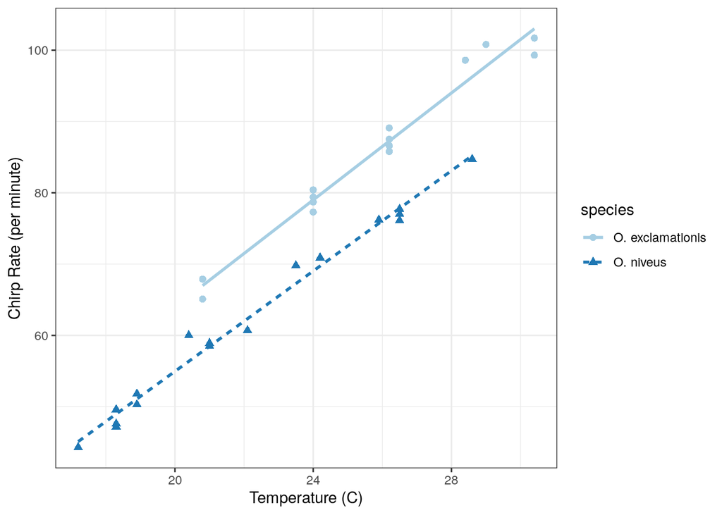

```r
p <-
  ggplot(
    crickets,
    aes(x = temp, y = rate, color = species, shape = species, linetype = species)
  ) +
  geom_point(size = 2) +
  geom_smooth(method = lm, se = FALSE, alpha = 0.5) +
  scale_color_brewer(palette = "Paired") +
  theme_bw() +
  labs(x = "Temperature (C)", y = "Chirp Rate (per minute)")
p
```

R的formula提供好多语法糖：

- `y ~ x + z + x:z`可以简写成`y ~ (x + z)^2`或者`y ~ x * z`，
- `y ~ (x + z + w)^3`包括了所有单因素，双因素和三因素组合
- `y ~ (.)^3` 所有不在波浪号左边的变量都被包含在`.`里
- `y ~ I( (Celsius * 9/5) + 32 )`从摄氏转华氏，用`I()`函数引入计算，或者其它更华丽的函数

```r
# help(formula)
```

回到例子：

```r
interaction_fit <- lm(rate ~ (temp + species)^2, data = crickets)

print(interaction_fit)
```

```
##
## Call:
## lm(formula = rate ~ (temp + species)^2, data = crickets)
##
## Coefficients:
##           (Intercept)                   temp       speciesO. niveus
##               -11.041                  3.751                 -4.348
## temp:speciesO. niveus
##                -0.234
```

下推论之前，应该先诊断模型！

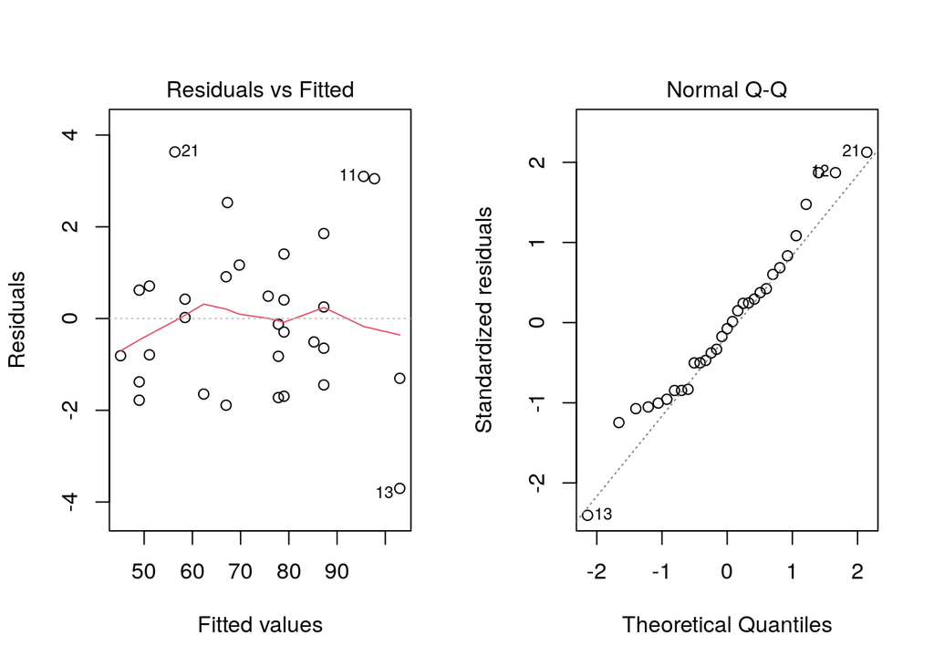

```r
par(mfrow = c(1, 2))

# Show residuals vs predicted values:
plot(interaction_fit, which = 1)
# A normal quantile plot on the residuals:
plot(interaction_fit, which = 2)
```

测试一个不怎么地的模型：

```r
# 去掉了interaction
main_effect_fit <-  lm(rate ~ temp + species, data = crickets)

anova(main_effect_fit, interaction_fit)  # 方差分析
```

|  | Res.Df | RSS | Df | Sum of Sq | F | Pr(>F) |
| --- | --- | --- | --- | --- | --- | --- |
| 1 | 28 | 89.34987 | NA | NA | NA | NA |
| 2 | 27 | 85.07409 | 1 | 4.275779 | 1.357006 | 0.2542464 |

p值为0.25，不能否定原假设（两个模型没差别），说明两个模型没差别，说明interaction影响不大。

别忘了做模型诊断：

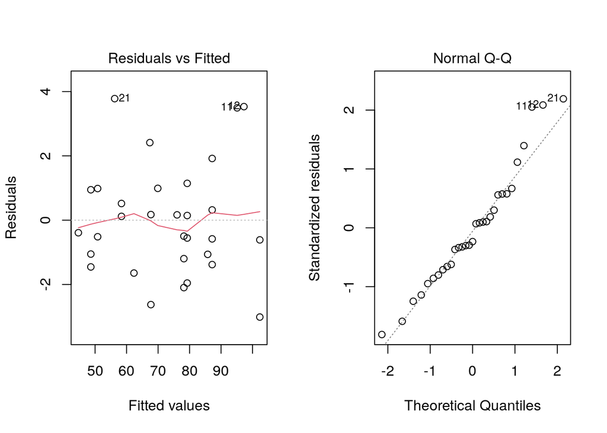

```r
par(mfrow = c(1, 2))
plot(main_effect_fit, which = 1)
plot(main_effect_fit, which = 2)
```

模型的更多统计信息：

```r
summary(main_effect_fit)
```

```
##
## Call:
## lm(formula = rate ~ temp + species, data = crickets)
##
## Residuals:
##     Min      1Q  Median      3Q     Max
## -3.0128 -1.1296 -0.3912  0.9650  3.7800
##
## Coefficients:
##                   Estimate Std. Error t value Pr(>|t|)
## (Intercept)       -7.21091    2.55094  -2.827  0.00858 **
## temp               3.60275    0.09729  37.032  < 2e-16 ***
## speciesO. niveus -10.06529    0.73526 -13.689 6.27e-14 ***
## ---
## Signif. codes:  0 '***' 0.001 '**' 0.01 '*' 0.05 '.' 0.1 ' ' 1
##
## Residual standard error: 1.786 on 28 degrees of freedom
## Multiple R-squared:  0.9896, Adjusted R-squared:  0.9888
## F-statistic:  1331 on 2 and 28 DF,  p-value: < 2.2e-16
```

解释：

- 气温每变化1（摄氏度），这两个种的蟋蟀叫叫频率都上升3.6，p值显著
- 在所有温度下，O.niveus的叫叫频率比O. exclamationis小10，同样p值显著
- 截距：两个种的蟋蟀在0摄氏度时叫叫频率为`-7.2`，这个外推（extrapolation）明显不对。所以该模型只在检测的温度区间内比较合理。

如果需要预测的话，可以用`predict()`函数：

```r
tb_new_value <- tibble(species = "O. exclamationis", temp = 15:20)
predict(main_effect_fit, tb_new_value)
```

```
##        1        2        3        4        5        6
## 46.83039 50.43314 54.03589 57.63865 61.24140 64.84415
```

## R modeling系统的问题

最大的问题就是inconsistency吧，不同作者开发的package有各自的习惯，对缺失值的处理也各不相同。

```r
# 引入缺失值
tb_new_value$temp[1] <- NA

predict(main_effect_fit, tb_new_value)
```

```
##        1        2        3        4        5        6
##       NA 50.43314 54.03589 57.63865 61.24140 64.84415
```

换一种缺失值处理方式：

```r
predict(main_effect_fit, tb_new_value, na.action = na.fail)
```

```
## Error in na.fail.default(structure(list(temp = c(NA, 16L, 17L, 18L, 19L, : missing values in object
```

再换一种：

```r
predict(main_effect_fit, tb_new_value, na.action = na.omit)
```

```
##        2        3        4        5        6
## 50.43314 54.03589 57.63865 61.24140 64.84415
```

## 结合`tidymodel`和`base R`

`tidymodels`提供一系列接口，让模型结果格式符合`tidyverse`的设计理念：

```r
corr_res <- purrr::map(
  .x = mtcars %>% select(-mpg),
  .f = ~ cor.test(x = .x, y = mtcars$mpg)
)

length(corr_res)  # a list of length 10
```

```
## [1] 10
```

```r
corr_res[[1]]
```

```
##
##  Pearson's product-moment correlation
##
## data:  .x and mtcars$mpg
## t = -8.9197, df = 30, p-value = 6.113e-10
## alternative hypothesis: true correlation is not equal to 0
## 95 percent confidence interval:
##  -0.9257694 -0.7163171
## sample estimates:
##       cor
## -0.852162
```

用`tidymodels`整理上述模型：

```r
broom::tidy(corr_res[[1]])
```

| estimate | statistic | p.value | parameter | conf.low | conf.high | method | alternative |
| --- | --- | --- | --- | --- | --- | --- | --- |
| -0.852162 | -8.919699 | 6.112687e-10 | 30 | -0.9257694 | -0.7163171 | Pearson's product-moment correlation | two.sided |

批量整理顺便画图：

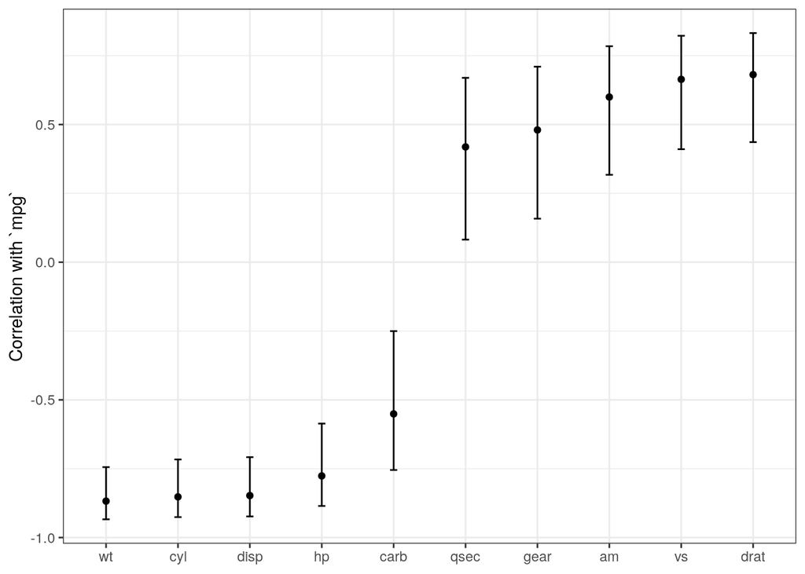

```r
corr_res %>%
  purrr::map_dfr(.f = broom::tidy, .id = "predictor") %>%
  ggplot(aes(x = fct_reorder(predictor, estimate))) +
  geom_point(aes(y = estimate)) +
  geom_errorbar(aes(ymin = conf.low, ymax = conf.high), width = 0.1) +
  theme_bw() +
  labs(x = NULL, y = "Correlation with `mpg`")
```

另一个例子：使用`crickets`数据，但是对不同种分开建模。

```r
data_by_species <-
  crickets %>%
  group_nest(species)
glimpse(data_by_species)
```

```
## Rows: 2
## Columns: 2
## $ species <fct> O. exclamationis, O. niveus
## $ data    <list<tibble[,2]>> [<tbl_df[14 x 2]>], [<tbl_df[17 x 2]>]
```

这里用到了`dplyr`的`list-column`功能。

```r
model_by_species <-
  data_by_species %>%
  mutate(
    model = purrr::map(data, .f = ~ lm(rate ~ temp, data = .x))
  )
model_by_species
```

| species | data | model |
| --- | --- | --- |
| O. exclamationis | > |  |
| O. niveus | > |  |

```r
model_by_species %>%
  mutate(coef = purrr::map(model, .f = broom::tidy)) %>%
  select(species, coef) %>%
  unnest(cols = c(coef))
```

| species | term | estimate | std.error | statistic | p.value |
| --- | --- | --- | --- | --- | --- |
| O. exclamationis | (Intercept) | -11.040848 | 4.7654774 | -2.316840 | 3.898993e-02 |
| O. exclamationis | temp | 3.751447 | 0.1838038 | 20.410068 | 1.100375e-10 |
| O. niveus | (Intercept) | -15.389255 | 2.3467153 | -6.557785 | 9.074321e-06 |
| O. niveus | temp | 3.517462 | 0.1047334 | 33.584894 | 1.565616e-15 |

见证`tidymodels`：

```r
library(tidymodels)
```